# Exploratory Data Analysis — EIA RECS 2020

**Project:** Beyond Correlation in Energy Data — the heterogeneous causal effect of **energy-efficient windows** on residential energy intensity.

**Data:** [U.S. Energy Information Administration, Residential Energy Consumption Survey 2020](https://www.eia.gov/consumption/residential/data/2020/). 17,196 U.S. households after filtering; processed by `../data/load_recs.py`. Real, nationally representative survey data — public domain.

This notebook covers: dataset overview, missing values, feature distributions, correlations, possible biases, and the confounding pattern that motivates the causal approach.

```python
import pandas as pd, numpy as np, matplotlib.pyplot as plt, seaborn as sns
plt.rcParams['axes.unicode_minus'] = False
sns.set_style('whitegrid')
df = pd.read_csv('../data/recs2020_processed.csv')
print('shape:', df.shape)
df.head()
```

```
shape: (17196, 11)
```

|  | household_id | efficient_windows | energy_intensity_kwh_m2 | floor_area_m2 | building_age | year_built | housing_type | climate_zone | cold_climate | household_size | income_bin |
| --- | --- | --- | --- | --- | --- | --- | --- | --- | --- | --- | --- |
| 0 | 100001 | 1 | 217.287972 | 195.09630 | 45.0 | 1975.0 | SF-Detached | Mixed-Dry | 0 | 2 | 13 |
| 1 | 100002 | 1 | 149.894579 | 54.81277 | 35.0 | 1985.0 | Apt-5plus | Mixed-Humid | 0 | 1 | 6 |
| 2 | 100003 | 0 | 107.780932 | 83.61270 | 55.0 | 1965.0 | Apt-5plus | Mixed-Dry | 0 | 1 | 11 |
| 3 | 100004 | 1 | 130.337578 | 195.09630 | 35.0 | 1985.0 | SF-Detached | Mixed-Humid | 0 | 2 | 10 |
| 4 | 100005 | 1 | 233.151795 | 74.32240 | 55.0 | 1965.0 | Apt-5plus | Mixed-Humid | 0 | 2 | 16 |

## Dataset overview & target variable

- **Treatment T — `efficient_windows`** (binary): 1 = double/triple-pane, 0 = single-pane. Recoded from RECS `TYPEGLASS`. Window replacement is a canonical energy-efficiency retrofit.
- **Outcome Y — `energy_intensity_kwh_m2`** (continuous): annual household energy use (all fuels) per m² of conditioned floor area. Derived from `TOTALBTU / TOTSQFT_EN`.
- **Covariates X:** floor area, building age, climate zone, housing type, household size, income bin.

```python
df.describe(include='all').T
```

|  | count | unique | top | freq | mean | std | min | 25% | 50% | 75% | max |
| --- | --- | --- | --- | --- | --- | --- | --- | --- | --- | --- | --- |
| household_id | 17196.0 | NaN | NaN | NaN | 109254.384973 | 5343.7328 | 100001.0 | 104620.75 | 109261.5 | 113886.25 | 118496.0 |
| efficient_windows | 17196.0 | NaN | NaN | NaN | 0.677599 | 0.467409 | 0.0 | 0.0 | 1.0 | 1.0 | 1.0 |
| energy_intensity_kwh_m2 | 17196.0 | NaN | NaN | NaN | 149.986869 | 81.228918 | 22.08552 | 93.574198 | 132.397663 | 187.218207 | 548.096691 |
| floor_area_m2 | 17196.0 | NaN | NaN | NaN | 180.618051 | 106.513305 | 22.29672 | 102.1933 | 157.9351 | 232.2575 | 1393.545 |
| building_age | 17196.0 | NaN | NaN | NaN | 41.530007 | 21.76034 | 5.0 | 25.0 | 45.0 | 55.0 | 75.0 |
| year_built | 17196.0 | NaN | NaN | NaN | 1978.469993 | 21.76034 | 1945.0 | 1965.0 | 1975.0 | 1995.0 | 2015.0 |
| housing_type | 17196 | 5 | SF-Detached | 11467 | NaN | NaN | NaN | NaN | NaN | NaN | NaN |
| climate_zone | 17196 | 8 | Cold | 6623 | NaN | NaN | NaN | NaN | NaN | NaN | NaN |
| cold_climate | 17196.0 | NaN | NaN | NaN | 0.41719 | 0.493109 | 0.0 | 0.0 | 0.0 | 1.0 | 1.0 |
| household_size | 17196.0 | NaN | NaN | NaN | 2.452954 | 1.366933 | 1.0 | 1.0 | 2.0 | 3.0 | 7.0 |
| income_bin | 17196.0 | NaN | NaN | NaN | 11.587113 | 4.028111 | 1.0 | 9.0 | 13.0 | 15.0 | 16.0 |

## Missing values (after ETL — should be zero)

```python
miss = df.isna().sum()
print(miss[miss>0] if (miss>0).any() else 'no missing values')
```

```
no missing values
```

## Outcome and treatment distributions

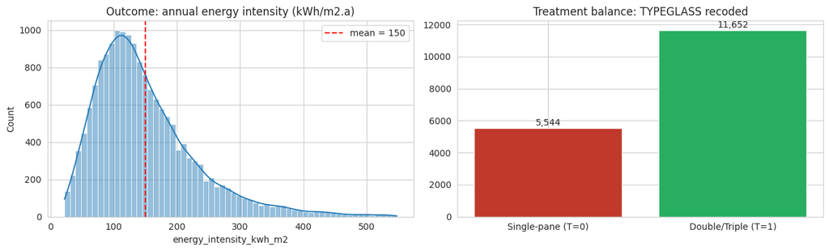

```python
fig, ax = plt.subplots(1, 2, figsize=(13, 4))
sns.histplot(df['energy_intensity_kwh_m2'], kde=True, ax=ax[0], color='#2c7fb8', bins=60)
ax[0].set_title('Outcome: annual energy intensity (kWh/m2.a)')
ax[0].axvline(df['energy_intensity_kwh_m2'].mean(), color='red', ls='--', label=f"mean = {df.energy_intensity_kwh_m2.mean():.0f}")
ax[0].legend()
counts = df['efficient_windows'].value_counts().sort_index()
ax[1].bar(['Single-pane (T=0)', 'Double/Triple (T=1)'], counts.values, color=['#c0392b', '#27ae60'])
for i, v in enumerate(counts.values): ax[1].text(i, v+150, f'{v:,}', ha='center')
ax[1].set_title('Treatment balance: TYPEGLASS recoded')
plt.tight_layout(); plt.savefig('eda_outcome_treatment.png', dpi=150, bbox_inches='tight'); plt.show()
```

## Feature distributions

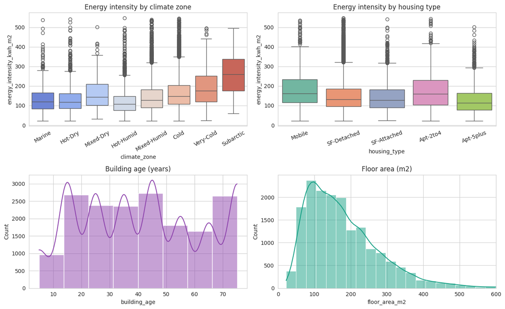

```python
fig, ax = plt.subplots(2, 2, figsize=(13, 8))
sns.boxplot(data=df, x='climate_zone', y='energy_intensity_kwh_m2', ax=ax[0,0],
            order=['Marine','Hot-Dry','Mixed-Dry','Hot-Humid','Mixed-Humid','Cold','Very-Cold','Subarctic'],
            palette='coolwarm')
ax[0,0].set_title('Energy intensity by climate zone'); ax[0,0].tick_params(axis='x', rotation=30)
sns.boxplot(data=df, x='housing_type', y='energy_intensity_kwh_m2', ax=ax[0,1],
            order=['Mobile','SF-Detached','SF-Attached','Apt-2to4','Apt-5plus'], palette='Set2')
ax[0,1].set_title('Energy intensity by housing type'); ax[0,1].tick_params(axis='x', rotation=20)
sns.histplot(df['building_age'], kde=True, ax=ax[1,0], color='#8e44ad', bins=8)
ax[1,0].set_title('Building age (years)')
sns.histplot(df['floor_area_m2'], kde=True, ax=ax[1,1], color='#16a085', bins=50)
ax[1,1].set_title('Floor area (m2)'); ax[1,1].set_xlim(0, 600)
plt.tight_layout(); plt.show()
```